# Practical Machine Learning project: predicting how well users perform certain exercises

### Sergey Prykhozhij

April 30th, 2017

## Background

Using devices such as Jawbone Up, Nike FuelBand, and Fitbit it is now possible to collect a large amount of data about personal activity relatively inexpensively. These type of devices are part of the quantified self movement - a group of enthusiasts who take measurements about themselves regularly to improve their health, to find patterns in their behavior, or because they are tech geeks. One thing that people regularly do is quantify how much of a particular activity they do, but they rarely quantify how well they do it. Research in this area also focuses on developing the ways to identify which activity people do. In some aspects, the ability to identify how well people do a certain activity may be similar to the ability to identify which activity people do.

In this project, the goal will be to use data from accelerometers on the belt, forearm, arm, and dumbell of 6 participants. They were asked to perform barbell lifts correctly and incorrectly in 5 different ways. Investigating how well someone does an activity can be useful for many applications such as sports training. In the research paper related to the project dataset, the authors investigate three aspects that pertain to qualitative activity recognition: the problem of specifying correct execution, the automatic and robust detection of execution mistakes, and how to provide feedback on the quality of execution to the user. Six young health participants were asked to perform one set of 10 repetitions of the Unilateral Dumbbell Biceps Curl in five different fashions: exactly according to the specification (Class A), throwing the elbows to the front (Class B), lifting the dumbbell only halfway (Class C), lowering the dumbbell only halfway (Class D) and throwing the hips to the front (Class E). Class A corresponds to the specified execution of the exercise, while the other 4 classes correspond to common mistakes. Participants were supervised by an experienced weight lifter to make sure the execution complied to the manner they were supposed to simulate. The exercises were performed by six male participants aged between 20-28 years, with little weight lifting experience. We made sure that all participants could easily simulate the mistakes in a safe and controlled manner by using a relatively light dumbbell (1.25kg).

The above information is either quoted directly or paraphrased from http://groupware.les.inf.puc-rio.br/har.

## Data reading, processing and cleaning

Before the data can be used for machine learning applications, it is often necessary to prepare it by performing a number of steps related to its processing, cleaning and feature selection. These steps can be very important for successful machine learning applications because they allow the learning algorithms to focus on the most relevant parts of the datasets

### Loading packages and reading data

All relevant packages have been loaded and the datasets have been imported. Their dimensions were output.

```r
library(corrplot)
library(caret)
library(rpart)
library(randomForest)

# reading the data
training <- read.csv("https://d396qusza40orc.cloudfront.net/predmachlearn/pml-training.csv", header = TRUE)
testing <- read.csv("https://d396qusza40orc.cloudfront.net/predmachlearn/pml-testing.csv", header = TRUE)

dim(training)
```

```
## [1] 19622   160
```

```r
dim(testing)
```

```
## [1]  20 160
```

### Exploring data, cleaning and feature selection based on several criteria

The simplest exploration of data is to simply output a sample of it as in the case of training dataset and the whole dataset in the case of testing data. In addition, summary function is useful to assess the overall distribution of values. Since the output is very bulky, it was not included. The conclusion was that there are many columns that are completely filled with “NA” or empty string values. These columns are unlikely to be useful for predicting the type of activity using the testing data.

```r
# exploring data before cleaning
head(training)
head(testing)
summary(training)
summary(testing)
```

They were therefore removed from both datasets.

```r
colsNotNAs <- colSums(is.na(testing)) != nrow(testing)
training <- training[, colsNotNAs]
testing <- testing[, colsNotNAs]
```

It is obvious that the column dimension of both datasets was reduced by 100.

```r
dim(training)
```

```
## [1] 19622    60
```

```r
dim(testing)
```

```
## [1] 20 60
```

Another possible feature selection for these datasets can be based on the knowledge about which parts of the body were exercised. From the background to the project it is known that belt, forearm, arm, and dumbell accelerometers were involved in relevant measurements

```r
col.names <- names(training)

col.names.train <- c(col.names[grepl("belt|arm|dumbbell", col.names)], "classe")
col.names.test <- col.names[grepl("belt|arm|dumbbell", col.names)]

training <- training[, col.names.train]
testing  <- testing[, col.names.test]
```

Now is the time to investigate the relationships between different potential predictor variables and the response “classe” variable. FeaturePlot function does not show clear trends between exercise classes and any individual variables. On the other hand, the correlation plot shows clusters of correlation between related variables suggesting that it may be possible to distinguish different classes of activities based on multiple parameters. Finally, there were no clear near-zero variables. Thus, the dataset looks ready to be used for fitting models and cross-validation.

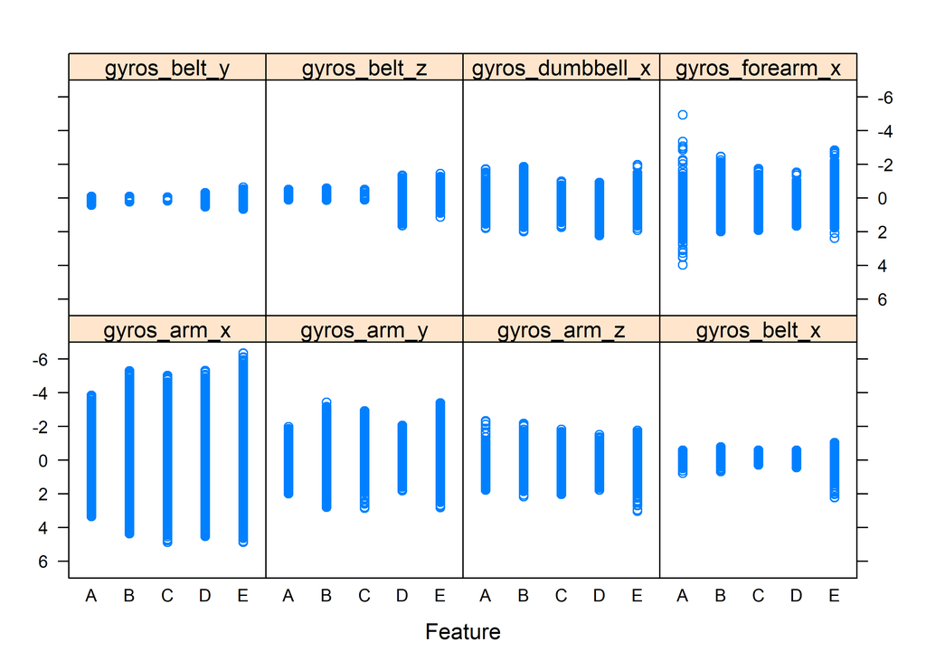

```r
# trying to see if there is a clear visualizable relationship between
# particular valiables and the response variable
library(caret)

# classify the variables according to their scale using the maximum function
colMaxs <- sapply(training[,-53], max)
colsSmall <- colMaxs < 10
colsMedium <- (colMaxs > 10 & colMaxs < 300)
colsLarge <- colMaxs > 300

trainNoClasse <- training[,-53]

featurePlot(trainNoClasse[,colsSmall], training$classe, "strip", ylim =c(7, -7))
```

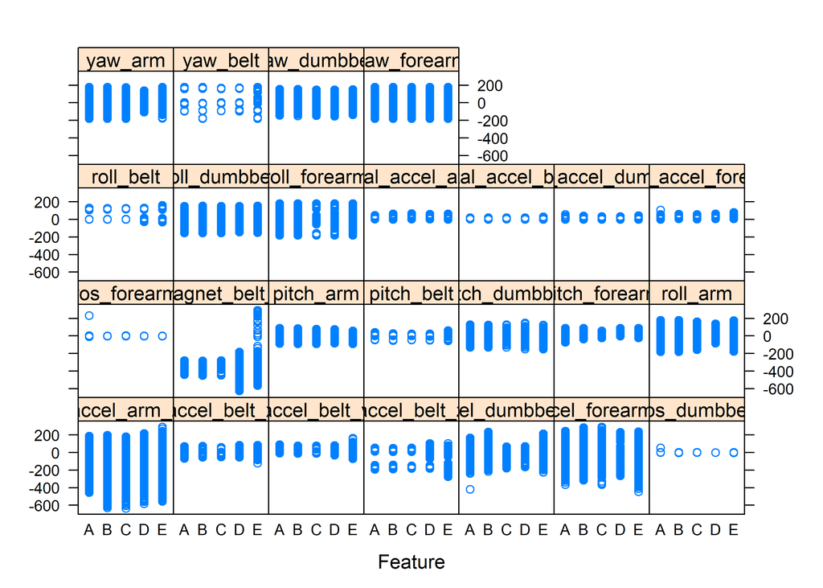

```r
featurePlot(trainNoClasse[,colsMedium], training$classe, "strip")
```

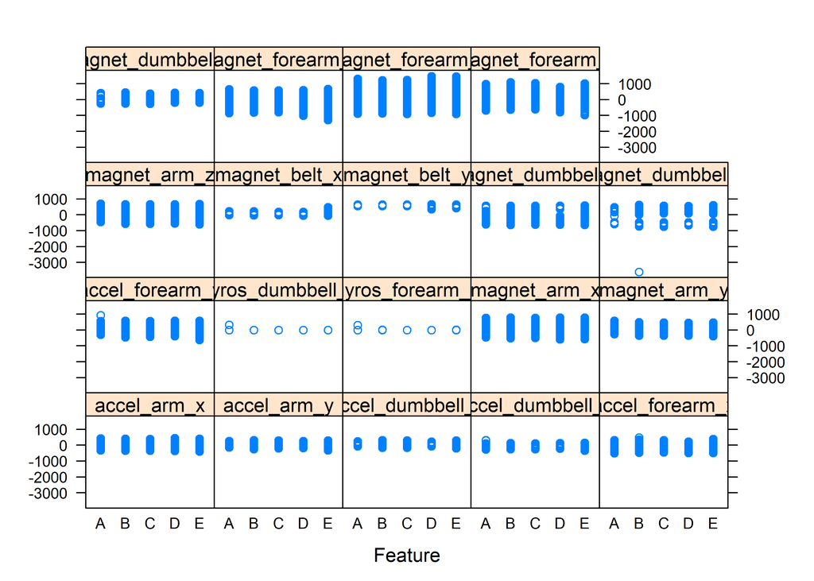

```r
featurePlot(trainNoClasse[,colsLarge], training$classe, "strip")
```

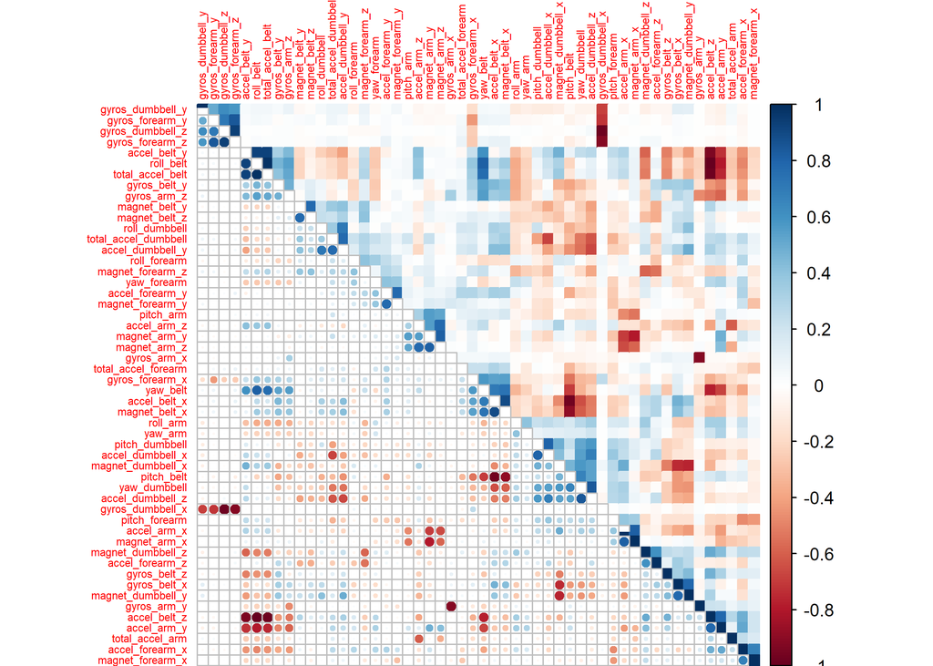

```r
# testing how much correlation there is between different varibles in the
# training dataset
corrplot.mixed(cor(training[, -53]), lower="circle", upper="color",
               tl.pos="lt", tl.cex = 0.5, diag="n", order="hclust", hclust.method="complete")
```

```r
# checking for near-zero variance
zero.var = nearZeroVar(training, saveMetrics=TRUE)
zero.var
```

```
##                      freqRatio percentUnique zeroVar   nzv
## roll_belt             1.101904     6.7781062   FALSE FALSE
## pitch_belt            1.036082     9.3772296   FALSE FALSE
## yaw_belt              1.058480     9.9734991   FALSE FALSE
## total_accel_belt      1.063160     0.1477933   FALSE FALSE
## gyros_belt_x          1.058651     0.7134849   FALSE FALSE
## gyros_belt_y          1.144000     0.3516461   FALSE FALSE
## gyros_belt_z          1.066214     0.8612782   FALSE FALSE
## accel_belt_x          1.055412     0.8357966   FALSE FALSE
## accel_belt_y          1.113725     0.7287738   FALSE FALSE
## accel_belt_z          1.078767     1.5237998   FALSE FALSE
## magnet_belt_x         1.090141     1.6664968   FALSE FALSE
## magnet_belt_y         1.099688     1.5187035   FALSE FALSE
## magnet_belt_z         1.006369     2.3290184   FALSE FALSE
## roll_arm             52.338462    13.5256345   FALSE FALSE
## pitch_arm            87.256410    15.7323412   FALSE FALSE
## yaw_arm              33.029126    14.6570176   FALSE FALSE
## total_accel_arm       1.024526     0.3363572   FALSE FALSE
## gyros_arm_x           1.015504     3.2769341   FALSE FALSE
## gyros_arm_y           1.454369     1.9162165   FALSE FALSE
## gyros_arm_z           1.110687     1.2638875   FALSE FALSE
## accel_arm_x           1.017341     3.9598410   FALSE FALSE
## accel_arm_y           1.140187     2.7367241   FALSE FALSE
## accel_arm_z           1.128000     4.0362858   FALSE FALSE
## magnet_arm_x          1.000000     6.8239731   FALSE FALSE
## magnet_arm_y          1.056818     4.4439914   FALSE FALSE
## magnet_arm_z          1.036364     6.4468454   FALSE FALSE
## roll_dumbbell         1.022388    84.2065029   FALSE FALSE
## pitch_dumbbell        2.277372    81.7449801   FALSE FALSE
## yaw_dumbbell          1.132231    83.4828254   FALSE FALSE
## total_accel_dumbbell  1.072634     0.2191418   FALSE FALSE
## gyros_dumbbell_x      1.003268     1.2282132   FALSE FALSE
## gyros_dumbbell_y      1.264957     1.4167771   FALSE FALSE
## gyros_dumbbell_z      1.060100     1.0498420   FALSE FALSE
## accel_dumbbell_x      1.018018     2.1659362   FALSE FALSE
## accel_dumbbell_y      1.053061     2.3748853   FALSE FALSE
## accel_dumbbell_z      1.133333     2.0894914   FALSE FALSE
## magnet_dumbbell_x     1.098266     5.7486495   FALSE FALSE
## magnet_dumbbell_y     1.197740     4.3012945   FALSE FALSE
## magnet_dumbbell_z     1.020833     3.4451126   FALSE FALSE
## roll_forearm         11.589286    11.0895933   FALSE FALSE
## pitch_forearm        65.983051    14.8557741   FALSE FALSE
## yaw_forearm          15.322835    10.1467740   FALSE FALSE
## total_accel_forearm   1.128928     0.3567424   FALSE FALSE
## gyros_forearm_x       1.059273     1.5187035   FALSE FALSE
## gyros_forearm_y       1.036554     3.7763735   FALSE FALSE
## gyros_forearm_z       1.122917     1.5645704   FALSE FALSE
## accel_forearm_x       1.126437     4.0464784   FALSE FALSE
## accel_forearm_y       1.059406     5.1116094   FALSE FALSE
## accel_forearm_z       1.006250     2.9558659   FALSE FALSE
## magnet_forearm_x      1.012346     7.7667924   FALSE FALSE
## magnet_forearm_y      1.246914     9.5403119   FALSE FALSE
## magnet_forearm_z      1.000000     8.5771073   FALSE FALSE
## classe                1.469581     0.0254816   FALSE FALSE
```

### Training and cross-validation of models

As a first step before training and understanding models, the levels of the “classe” variable need to be converted back to their correct state.

```r
levels(training$classe) <- c("A", "B", "C", "D", "E")
training$classe <- as.factor(training$classe)
```

In terms of cross-validation, the problem with the current training and testing datasets is that the testing dataset is really small so out-of-sample error cannot be reliably estimates. Thus we need to train our models on the bulk of the data and validate them on a significant proportion of the data.

```r
# preparing the data for cross-validation
trainIndex <- createDataPartition(y = training$classe, p = 0.7, list = FALSE)
trainData <- training[trainIndex, ]
dim(trainData)
```

```
## [1] 13737    53
```

```r
validTestData <- training[-trainIndex,]
dim(validTestData)
```

```
## [1] 5885   53
```

The first model that we are going to try is decision tree classfication model.

```r
# decision tree model
modFit <- rpart(classe ~ ., data=trainData, method="class")

# confusion matrix for the rpart prediction
predsTrain <- predict(modFit, newdata = trainData, type = "class")
table(predsTrain, trainData$classe)
```

```
##
## predsTrain    A    B    C    D    E
##          A 3572  361   45   99   34
##          B  137 1543  126  186  201
##          C   98  283 1946  351  325
##          D   40  186  150 1443  132
##          E   59  285  129  173 1833
```

```r
# calculating the accuracy on the training dataset
mean(predsTrain == trainData$classe)
```

```
## [1] 0.7524933
```

```r
# calculating the confusion matrix and accuracy on the validation dataset
predsTest <- predict(modFit, newdata = validTestData, type = "class")
table(predsTest, validTestData$classe)
```

```
##
## predsTest    A    B    C    D    E
##         A 1498  163   25   44   19
##         B   80  669   48   81   87
##         C   48  114  822  175  149
##         D   21   76   62  584   49
##         E   27  117   69   80  778
```

```r
mean(predsTest == validTestData$classe)
```

```
## [1] 0.7393373
```

The model above has some merits but since we know that decision trees are not the most accurate models. Therefore, we can test if a more advanced random forest model would perform better on this dataset. We will still use the training and validation subsets of the original training dataset.

```r
# setting up cross-validation parameters
ctrl <- trainControl(method = 'cv', number = 3, verboseIter=F)

# random forest model
(randForest <- randomForest(classe~., data=trainData, ntree = 500))
```

```
##
## Call:
##  randomForest(formula = classe ~ ., data = trainData, ntree = 500)
##                Type of random forest: classification
##                      Number of trees: 500
## No. of variables tried at each split: 7
##
##         OOB estimate of  error rate: 0.47%
## Confusion matrix:
##      A    B    C    D    E class.error
## A 3902    3    0    0    1 0.001024066
## B    9 2647    2    0    0 0.004138450
## C    0   15 2379    2    0 0.007095159
## D    0    0   23 2226    3 0.011545293
## E    0    0    2    5 2518 0.002772277
```

```r
# predictions on the validation dataset to calculate the out-of-sample error
predsRF = predict(randForest, validTestData)

# confusion matrix and error
table(predsRF, validTestData$classe)
```

```
##
## predsRF    A    B    C    D    E
##       A 1673   12    0    0    0
##       B    1 1126    4    0    0
##       C    0    1 1020   28    1
##       D    0    0    2  935    1
##       E    0    0    0    1 1080
```

```r
1- mean(predsRF == validTestData$classe)
```

```
## [1] 0.0086661
```

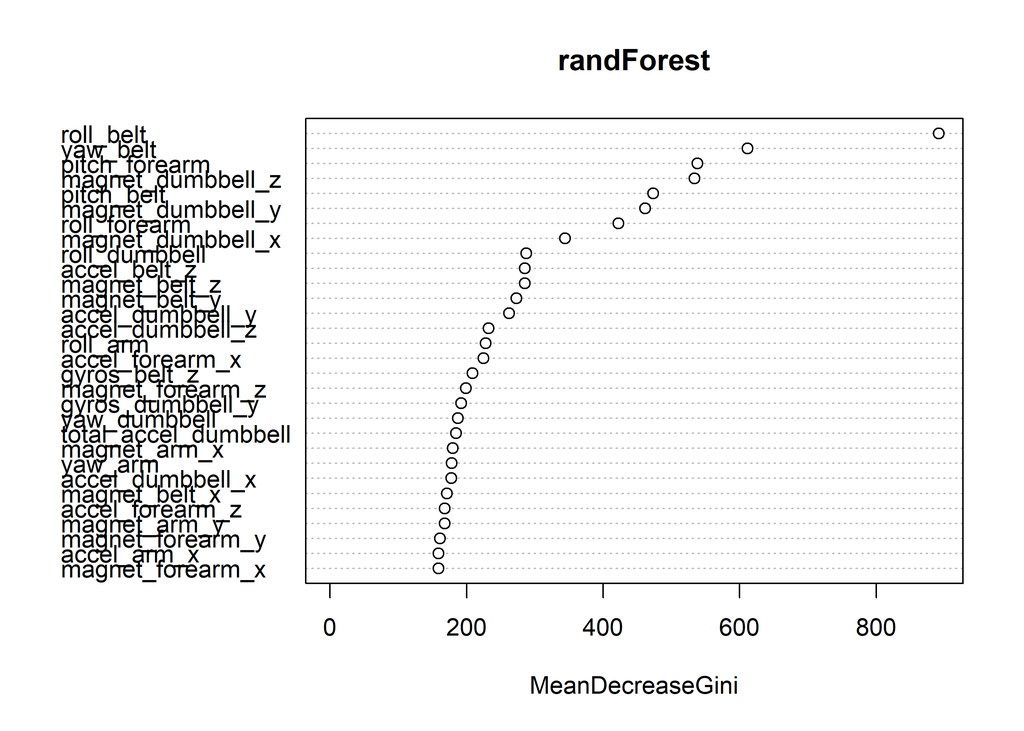

```r
# Investigating the individual variable importance
varImpPlot(randForest)
```

From this plot, it is clear that the model might have been simplified but on the other hand, the performance of the current is very good. The only downside of the current model is that it may take longer to be trained than a simpler model. However, if the model is going to be trained infrequently, the more complex model will be fine. Predictions usually occur fairly quickly.

As a final step in the project, we need to make predictions for the original testing data and submit them as answers to the project quiz.

```r
(predTesting <- predict(randForest, newdata = testing))
```

```
##  1  2  3  4  5  6  7  8  9 10 11 12 13 14 15 16 17 18 19 20
##  B  A  B  A  A  E  D  B  A  A  B  C  B  A  E  E  A  B  B  B
## Levels: A B C D E
```